# Elements of Statistics, Econometrics and Time Series Analysis (2017)

Assignment 2

Oleksandr Zaytsev

11/27/2017

```r
library(ggplot2)
```

# Problem 3: Linear regression analysis

In the light of the hot discussion on the educational system in Ukraine we consider here a data set on student performance at two schools in Portugal. The data set can be downloaded at http://archive.ics.uci.edu/ml/datasets/Student+Performance.

The zip-file contains some personal information and the grades in Mathematics (student-mat.csv) and Portuguese language (student-por.csv). Pick up the file for Math. The variable of interest is the final grade coded as G3. The remaining variables are used as explanatory variables. Hereafter we exclude G1 and G2 from the discussion and the analysis!

```r
student.mat <- read.csv('../../Data/student/student-mat.csv', sep = ';')

# Removing columns G1 and G2
student.mat <- subset(student.mat, select = -c(G1, G2))
```

Let’s familiarize ourselves with this dataset.

```r
summary(student.mat)
```

```
##  school   sex          age       address famsize   Pstatus      Medu
##  GP:349   F:208   Min.   :15.0   R: 88   GT3:281   A: 41   Min.   :0.000
##  MS: 46   M:187   1st Qu.:16.0   U:307   LE3:114   T:354   1st Qu.:2.000
##                   Median :17.0                             Median :3.000
##                   Mean   :16.7                             Mean   :2.749
##                   3rd Qu.:18.0                             3rd Qu.:4.000
##                   Max.   :22.0                             Max.   :4.000
##       Fedu             Mjob           Fjob            reason
##  Min.   :0.000   at_home : 59   at_home : 20   course    :145
##  1st Qu.:2.000   health  : 34   health  : 18   home      :109
##  Median :2.000   other   :141   other   :217   other     : 36
##  Mean   :2.522   services:103   services:111   reputation:105
##  3rd Qu.:3.000   teacher : 58   teacher : 29
##  Max.   :4.000
##    guardian     traveltime      studytime        failures      schoolsup
##  father: 90   Min.   :1.000   Min.   :1.000   Min.   :0.0000   no :344
##  mother:273   1st Qu.:1.000   1st Qu.:1.000   1st Qu.:0.0000   yes: 51
##  other : 32   Median :1.000   Median :2.000   Median :0.0000
##               Mean   :1.448   Mean   :2.035   Mean   :0.3342
##               3rd Qu.:2.000   3rd Qu.:2.000   3rd Qu.:0.0000
##               Max.   :4.000   Max.   :4.000   Max.   :3.0000
##  famsup     paid     activities nursery   higher    internet  romantic
##  no :153   no :214   no :194    no : 81   no : 20   no : 66   no :263
##  yes:242   yes:181   yes:201    yes:314   yes:375   yes:329   yes:132
##
##
##
##
##      famrel         freetime         goout            Dalc
##  Min.   :1.000   Min.   :1.000   Min.   :1.000   Min.   :1.000
##  1st Qu.:4.000   1st Qu.:3.000   1st Qu.:2.000   1st Qu.:1.000
##  Median :4.000   Median :3.000   Median :3.000   Median :1.000
##  Mean   :3.944   Mean   :3.235   Mean   :3.109   Mean   :1.481
##  3rd Qu.:5.000   3rd Qu.:4.000   3rd Qu.:4.000   3rd Qu.:2.000
##  Max.   :5.000   Max.   :5.000   Max.   :5.000   Max.   :5.000
##       Walc           health         absences            G3
##  Min.   :1.000   Min.   :1.000   Min.   : 0.000   Min.   : 0.00
##  1st Qu.:1.000   1st Qu.:3.000   1st Qu.: 0.000   1st Qu.: 8.00
##  Median :2.000   Median :4.000   Median : 4.000   Median :11.00
##  Mean   :2.291   Mean   :3.554   Mean   : 5.709   Mean   :10.42
##  3rd Qu.:3.000   3rd Qu.:5.000   3rd Qu.: 8.000   3rd Qu.:14.00
##  Max.   :5.000   Max.   :5.000   Max.   :75.000   Max.   :20.00
```

## Task 1

**Have a closer look at the definitions of the variables and analyze which of them might require a separate treatment. Consider for example the variables Mjob or goout. There are two possibilities how the variables can be included into the model (one with dummy variables, the other one without dummies). Think about these two approaches and suggest which approach is more appropriate for each of the variables MjOb or goout. Motivate your decision.**

In order to train a linear regression model, we need all our variables to be numeric. Some categorical variables (such as Mjob or school) are represented with strings. This means that the levels of these variables have to be encoded with numbers. We can do it either by simply enumerating the levels or by creating a dummy variable for each level (or n-1 dummy variables to replace a categorical variable with n levels). These are the two possibilities mentioned in task description.

There are two types of categorical variables:

*Ordinal* - the levels can be sorted (XS, S, M, L, XL) *Nominal* - with no specific order of levels (male, female)

The first approach described above is suitable for ordinal variables. Their order will be preserved by the numbers we assign to them. For example, clothing sizes can be ensoded with integers 1-5:

```r
sizes <- factor(c('XS', 'S', 'M', 'L', 'XL'))
sizes <- factor(sizes, levels = sizes, ordered = TRUE)
as.numeric(sizes)
```

```
## [1] 1 2 3 4 5
```

Second approach is better suited for nominal variables. If we encode them with integers, we introduce an order which is not natural for these variables. The better way is to use one-hot encoding or create dummy variables. For example

```r
sex <- factor(c('male', 'female'))
model.matrix(~sex)
```

```
##   (Intercept) sexmale
## 1           1       1
## 2           1       0
## attr(,"assign")
## [1] 0 1
## attr(,"contrasts")
## attr(,"contrasts")$sex
## [1] "contr.treatment"
```

```r
head(model.matrix(~student.mat$Mjob))
```

```
##   (Intercept) student.mat$Mjobhealth student.mat$Mjobother
## 1           1                      0                     0
## 2           1                      0                     0
## 3           1                      0                     0
## 4           1                      1                     0
## 5           1                      0                     1
## 6           1                      0                     0
##   student.mat$Mjobservices student.mat$Mjobteacher
## 1                        0                       0
## 2                        0                       0
## 3                        0                       0
## 4                        0                       0
## 5                        0                       0
## 6                        1                       0
```

## Task 2

**Consider now the dependent variable and the interval (metric) scaled explanatory variables. Plot these data and decide if you wish to transform these x-variables and if there is a need to transform the y variable. You can also use some measure of skewness to decide about y.**

## Task 3

**After making up your decision about the above two problems run a simple linear regression. If you wish to argue that farther’s job is insignificant and use the model with dummies than you have to check the simultaneous insignificance of all dummies which stem from the factor variable Fjob. Run a test for general linear hypothesis and conclude about the significance of Fjob.**

```r
# Regress y on all of the other variables in the dataset
model <- lm(G3 ~ ., data = student.mat)
summary(model)
```

```
##
## Call:
## lm(formula = G3 ~ ., data = student.mat)
##
## Residuals:
##      Min       1Q   Median       3Q      Max
## -13.0442  -1.9028   0.4289   2.7570   8.8874
##
## Coefficients:
##                  Estimate Std. Error t value Pr(>|t|)
## (Intercept)      14.07769    4.48089   3.142  0.00182 **
## schoolMS          0.72555    0.79157   0.917  0.35997
## sexM              1.26236    0.50003   2.525  0.01202 *
## age              -0.37516    0.21721  -1.727  0.08501 .
## addressU          0.55135    0.58412   0.944  0.34586
## famsizeLE3        0.70281    0.48824   1.439  0.15090
## PstatusT         -0.32010    0.72390  -0.442  0.65862
## Medu              0.45687    0.32317   1.414  0.15833
## Fedu             -0.10458    0.27762  -0.377  0.70663
## Mjobhealth        0.99808    1.11819   0.893  0.37268
## Mjobother        -0.35900    0.71316  -0.503  0.61500
## Mjobservices      0.65832    0.79784   0.825  0.40985
## Mjobteacher      -1.24149    1.03821  -1.196  0.23257
## Fjobhealth        0.34767    1.43796   0.242  0.80909
## Fjobother        -0.61967    1.02304  -0.606  0.54509
## Fjobservices     -0.46577    1.05697  -0.441  0.65972
## Fjobteacher       1.32619    1.29654   1.023  0.30707
## reasonhome        0.07851    0.55380   0.142  0.88735
## reasonother       0.77707    0.81757   0.950  0.34252
## reasonreputation  0.61304    0.57657   1.063  0.28839
## guardianmother    0.06978    0.54560   0.128  0.89830
## guardianother     0.75010    0.99946   0.751  0.45345
## traveltime       -0.24027    0.33897  -0.709  0.47889
## studytime         0.54952    0.28765   1.910  0.05690 .
## failures         -1.72398    0.33291  -5.179 3.75e-07 ***
## schoolsupyes     -1.35058    0.66693  -2.025  0.04361 *
## famsupyes        -0.86182    0.47869  -1.800  0.07265 .
## paidyes           0.33975    0.47775   0.711  0.47746
## activitiesyes    -0.32953    0.44494  -0.741  0.45942
## nurseryyes       -0.17730    0.54931  -0.323  0.74706
## higheryes         1.37045    1.07780   1.272  0.20437
## internetyes       0.49813    0.61956   0.804  0.42192
## romanticyes      -1.09449    0.46925  -2.332  0.02024 *
## famrel            0.23155    0.24593   0.942  0.34706
## freetime          0.30242    0.23735   1.274  0.20345
## goout            -0.59367    0.22451  -2.644  0.00855 **
## Dalc             -0.27223    0.33087  -0.823  0.41120
## Walc              0.26339    0.24801   1.062  0.28896
## health           -0.17678    0.16101  -1.098  0.27297
## absences          0.05629    0.02897   1.943  0.05277 .
## ---
## Signif. codes:  0 '***' 0.001 '**' 0.01 '*' 0.05 '.' 0.1 ' ' 1
##
## Residual standard error: 4.108 on 355 degrees of freedom
## Multiple R-squared:  0.2756, Adjusted R-squared:  0.196
## F-statistic: 3.463 on 39 and 355 DF,  p-value: 3.317e-10
```

[figure not shown]

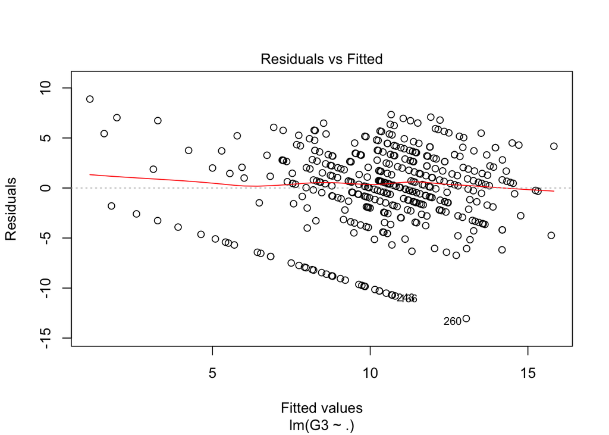

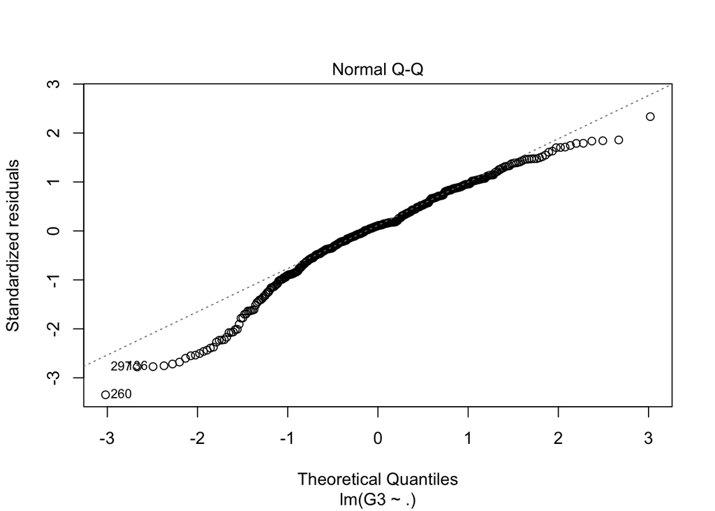

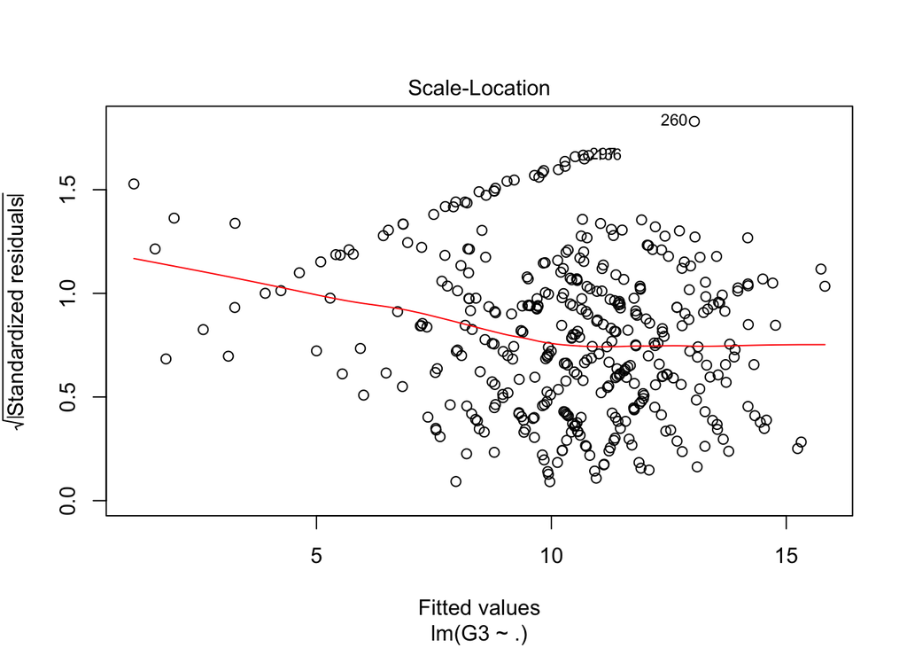

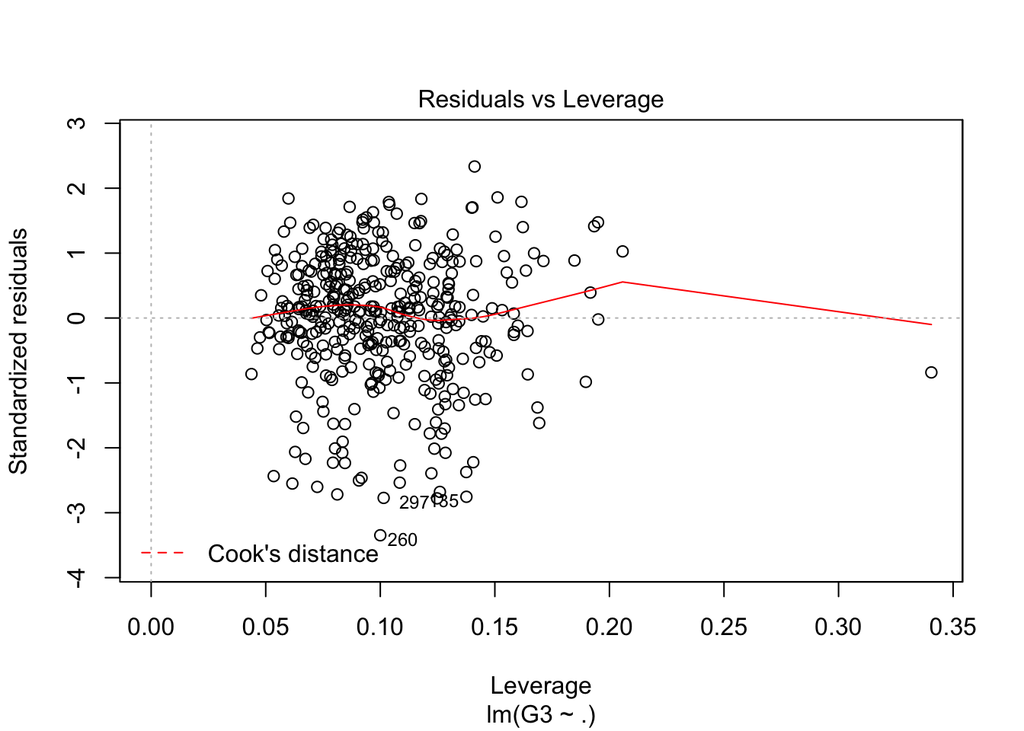

```r
plot(model)
```

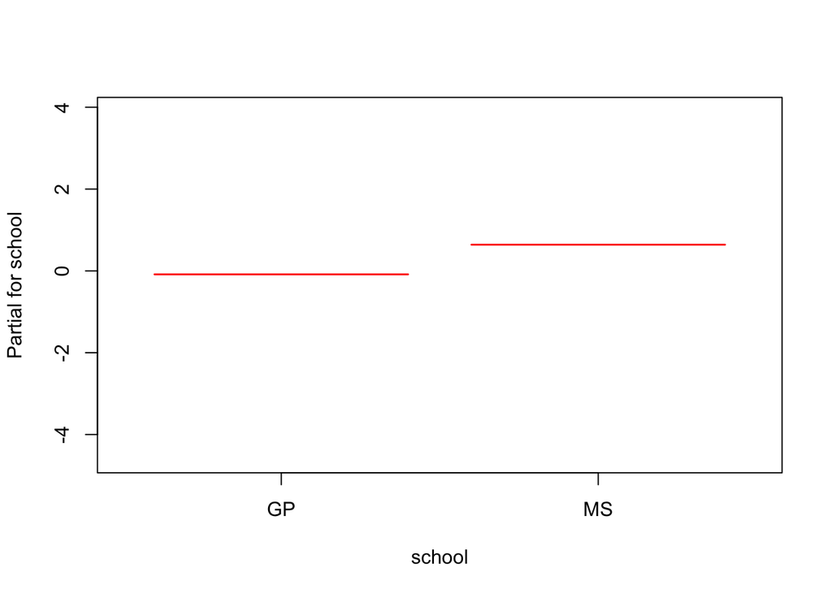

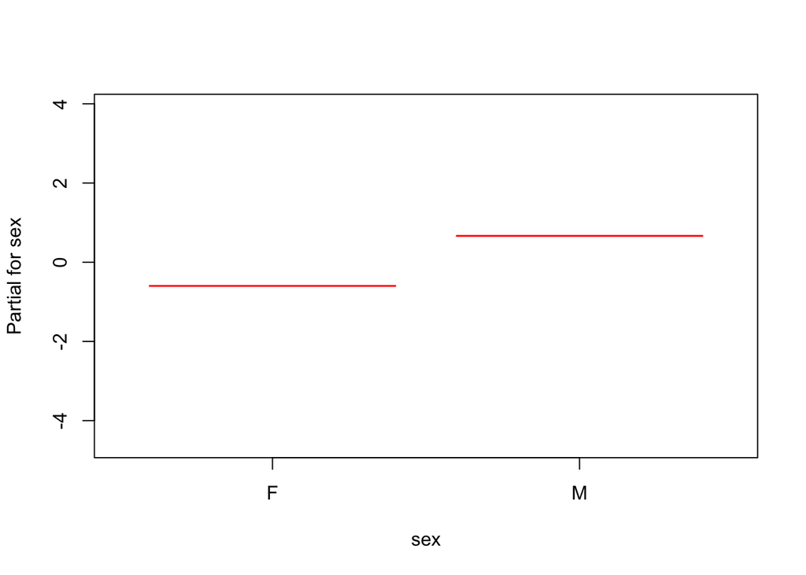

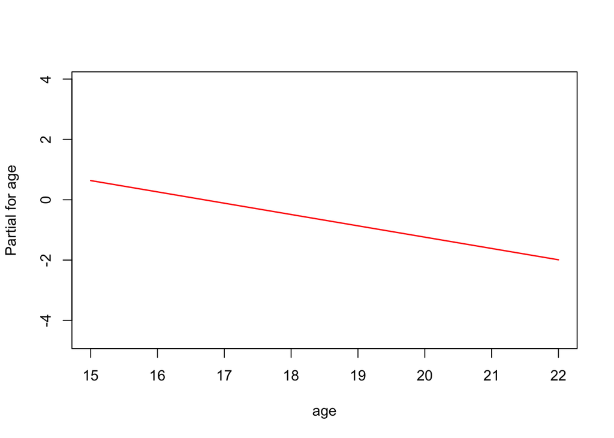

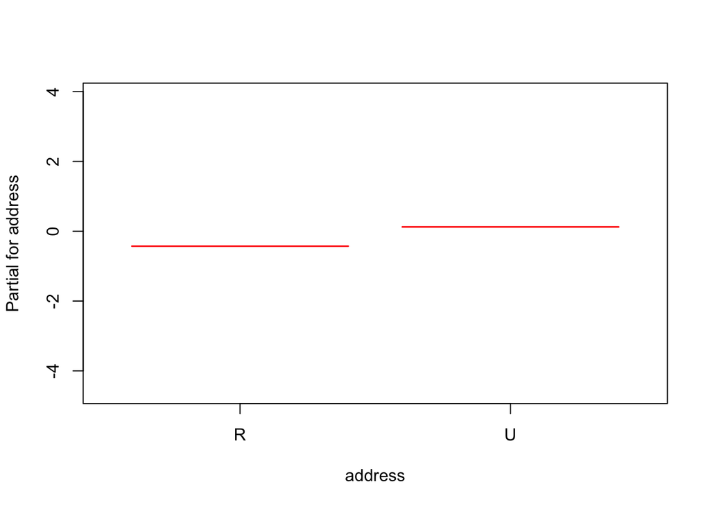

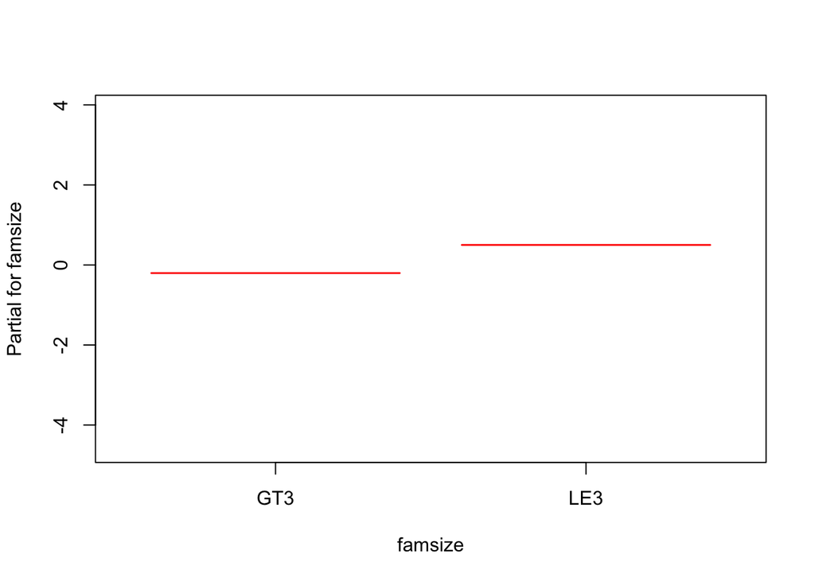

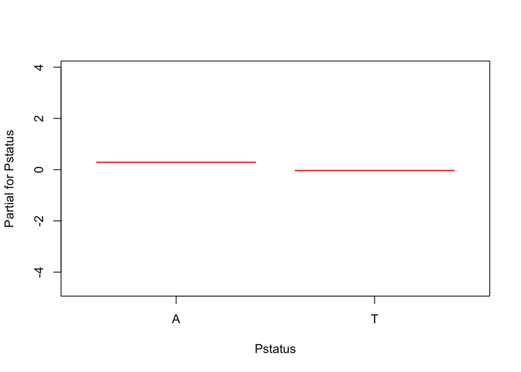

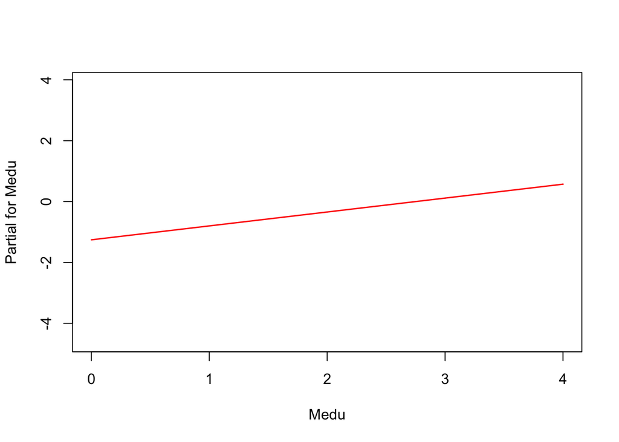

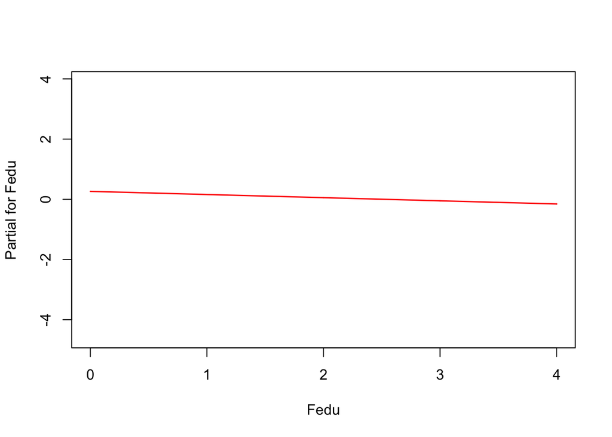

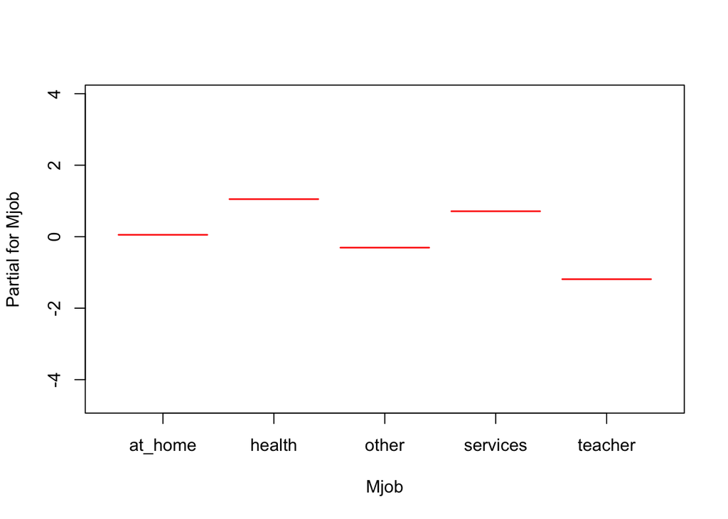

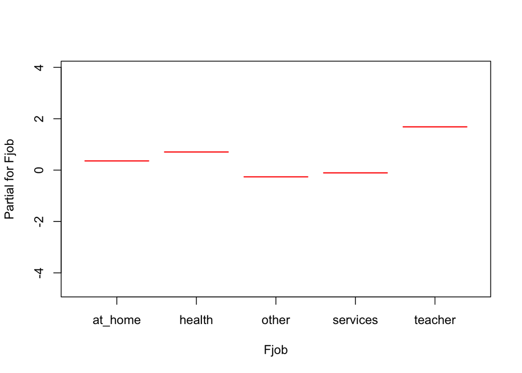

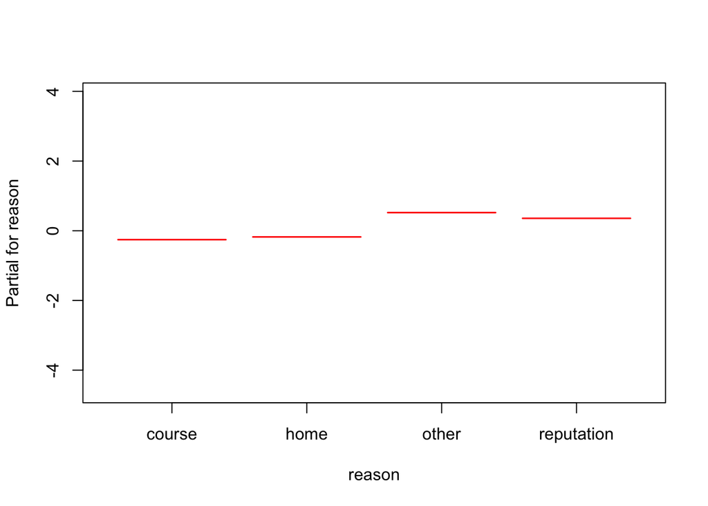

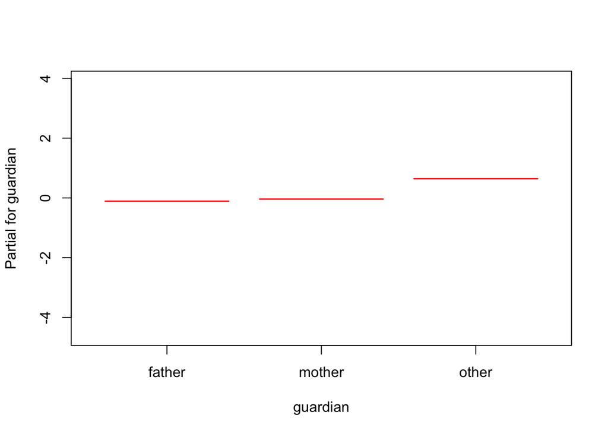

[18 more figures not shown]

```r
termplot(model)
```

## Task 4

**Provide an economic interpretation for the parameters of age, Fjob, and goout. Neglect the possible insignificance and keep in mind possible transformations of the variables.**

## Task 5

**Compute the 95% confidence intervals for the parameters of absences and famsup and provide its economic meaning. The CIs are computed relying on the assumption, that the residuals follow normal distribution. Is this assumption fulfilled? Run an appropriate goodness-of-fit test.**

```r
model <- lm(G3 ~ absences + famsup, data = student.mat)
confint(model, level = 0.95)
```

```
##                   2.5 %     97.5 %
## (Intercept)  9.73803820 11.3226638
## absences    -0.03661993  0.0769460
## famsupyes   -1.30753793  0.5558331
```

## Task 6

**Many of the variable appear insignificant and we should find the smallest model, which still has a good explanatory power. Choose this model using stepwise model selection (either based on the tests for R2 or using AIC/BIC). Pick up the last step of the model selection procedure and explain in details how the method/approach works (or is implemented in your software). Work with this model in all the remaining steps.**

```r
model <- lm(G3 ~ ., data = student.mat)
model <- step(model)
```

```
## Start:  AIC=1154.04
## G3 ~ school + sex + age + address + famsize + Pstatus + Medu +
##     Fedu + Mjob + Fjob + reason + guardian + traveltime + studytime +
##     failures + schoolsup + famsup + paid + activities + nursery +
##     higher + internet + romantic + famrel + freetime + goout +
##     Dalc + Walc + health + absences
##
##              Df Sum of Sq    RSS    AIC
## - reason      3     31.33 6022.2 1150.1
## - guardian    2     10.18 6001.0 1150.7
## - Fjob        4     80.83 6071.7 1151.3
## - nursery     1      1.76 5992.6 1152.2
## - Fedu        1      2.39 5993.2 1152.2
## - Pstatus     1      3.30 5994.1 1152.3
## - traveltime  1      8.48 5999.3 1152.6
## - paid        1      8.53 5999.4 1152.6
## - activities  1      9.26 6000.1 1152.7
## - internet    1     10.91 6001.7 1152.8
## - Dalc        1     11.42 6002.3 1152.8
## - school      1     14.18 6005.0 1153.0
## - famrel      1     14.96 6005.8 1153.0
## - address     1     15.04 6005.9 1153.0
## - Walc        1     19.03 6009.9 1153.3
## - health      1     20.34 6011.2 1153.4
## - higher      1     27.28 6018.1 1153.8
## - freetime    1     27.40 6018.2 1153.8
## <none>                    5990.8 1154.0
## - Medu        1     33.73 6024.6 1154.3
## - famsize     1     34.97 6025.8 1154.3
## - age         1     50.34 6041.2 1155.3
## - famsup      1     54.70 6045.5 1155.6
## - studytime   1     61.59 6052.4 1156.1
## - absences    1     63.73 6054.6 1156.2
## - schoolsup   1     69.21 6060.0 1156.6
## - Mjob        4    163.57 6154.4 1156.7
## - romantic    1     91.81 6082.6 1158.0
## - sex         1    107.56 6098.4 1159.1
## - goout       1    118.00 6108.8 1159.8
## - failures    1    452.56 6443.4 1180.8
##
```

[output cut: 488 more lines]

```
##             Df Sum of Sq    RSS    AIC
## <none>                   6278.4 1126.6
## - freetime   1     32.73 6311.1 1126.6
## - famsize    1     40.88 6319.3 1127.1
## - age        1     41.69 6320.1 1127.2
## - famsup     1     56.48 6334.9 1128.1
## - schoolsup  1     64.02 6342.4 1128.6
## - sex        1     72.33 6350.7 1129.1
## - absences   1     73.66 6352.1 1129.2
## - Medu       1     75.35 6353.7 1129.3
## - studytime  1     76.94 6355.3 1129.4
## - romantic   1     96.59 6375.0 1130.6
## - Mjob       4    196.96 6475.3 1130.8
## - goout      1    127.62 6406.0 1132.5
## - failures   1    628.39 6906.8 1162.2
```

## Task 7

**Sometimes data contains outliers which induces bias in the parameter estimates. Check for outliers using Cook’s distance and leverage. Have a closer look at the observation with the highest leverage (regardless if it is classified as an outlier or not). What makes this observation so outstanding (you may have a look at Box-plots for interval scaled variables or at the frequencies for binary/ordinal variables?**

```r
cooksd <- cooks.distance(model)
```

```r
#leverage.plots(model)
```

## Task 8

**Frequently data is missing. Pick up 5 rows in the data set and delete the value for age. Implement at least two approaches to fill in these values. Write down the corresponding formulas/model and give motivation for your approach. If you use standard routines then check how exactly the data imputation is implemented. How would you proceed if the value of the binary variable higher is missing? Implementation is not required.**

At this point there are no missing values in student.mat dataset.

```r
student.mat[!complete.cases(student.mat),]
```

| school | sex | age | address | famsize | Pstatus | Medu | Fedu | Mjob | Fjob | reason | guardian | traveltime | studytime | failures | schoolsup | famsup | paid | activities | nursery | higher | internet | romantic | famrel | freetime | goout | Dalc | Walc | health | absences | … |
| --- | --- | --- | --- | --- | --- | --- | --- | --- | --- | --- | --- | --- | --- | --- | --- | --- | --- | --- | --- | --- | --- | --- | --- | --- | --- | --- | --- | --- | --- | --- |

So we choose 5 rows at random and assingn the value of age to NA

```r
rows <- sample(1:nrow(student.mat), size=5, replace=FALSE)

# Create a copy of a data frame
student.mat.na <- data.frame(student.mat)
student.mat.na$age[rows] <- NA
```

```r
student.mat.na[!complete.cases(student.mat.na),]
```

|  | school | sex | age | address | famsize | Pstatus | Medu | Fedu | Mjob | Fjob | reason | guardian | traveltime | studytime | failures | schoolsup | famsup | paid | activities | nursery | higher | internet | romantic | famrel | freetime | goout | Dalc | Walc | health | … |
| --- | --- | --- | --- | --- | --- | --- | --- | --- | --- | --- | --- | --- | --- | --- | --- | --- | --- | --- | --- | --- | --- | --- | --- | --- | --- | --- | --- | --- | --- | --- |
| 29 | GP | M | NA | U | LE3 | A | 3 | 4 | services | other | home | mother | 1 | 2 | 0 | yes | yes | no | yes | yes | yes | yes | no | 5 | 3 | 3 | 1 | 1 | 5 | … |
| 94 | GP | F | NA | U | GT3 | T | 4 | 2 | teacher | services | home | mother | 2 | 2 | 0 | no | yes | yes | yes | yes | yes | yes | no | 5 | 3 | 3 | 1 | 1 | 1 | … |
| 168 | GP | F | NA | U | GT3 | T | 4 | 2 | health | services | home | father | 1 | 2 | 0 | no | no | yes | no | yes | yes | yes | yes | 4 | 2 | 3 | 1 | 1 | 3 | … |
| 233 | GP | M | NA | U | GT3 | T | 4 | 4 | teacher | teacher | reputation | mother | 1 | 2 | 0 | yes | yes | no | yes | yes | yes | yes | yes | 4 | 5 | 5 | 1 | 3 | 2 | … |
| 370 | MS | F | NA | R | GT3 | T | 4 | 4 | other | teacher | other | father | 3 | 2 | 0 | no | yes | yes | no | no | yes | yes | yes | 3 | 2 | 2 | 4 | 2 | 5 | … |

## Task 9

**Now we look at the model assumptions. The variable goout seems to be very significant. However, if we look at the residuals we observe that the variance of the residuals is rather different for different values of goout. Run the Bartlett’s test and compute the FGLS estimators assuming groupwise heteroscedasticity. Compare the results with the original model. Explain the advantages of the (F)GLS estimation.**

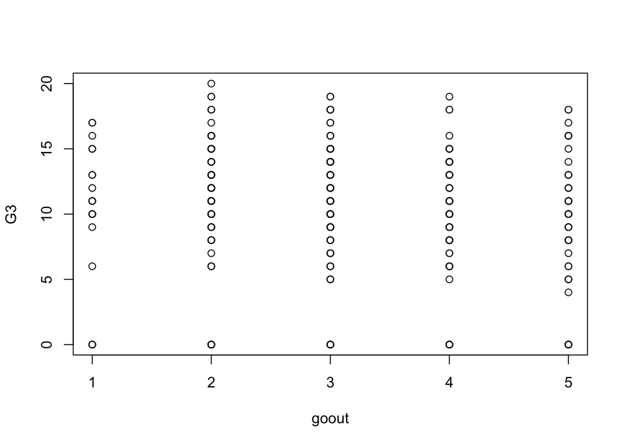

```r
plot(G3 ~ goout, data = student.mat)
```

## Task 10

**Compute the White estimator of covariance matrix of the OLS estimators. Run the t-tests and compare the results with the original model. Explain the advantages of the White estimator for the variance.**

## Task 11

**Write a short summary with the pedagogical and political interpretation of the estimated model.**

# Problem 4: further issues + some theory

# Monte-Carlo simulation: asymptotic properties of the OLS estimators

We postulate the true regression model in the form
$$y_{t} = 1 + 2 \cdot x_{1t} + 3 \cdot x_{2t} + u_{t}$$

Consider two setups of the simulation study. (A) Draw $x_{1t}$ from $N(0, 0.4)$ and $x_{2t}$ from $N(0, 0.8)$ in such way that $Corr(x_{1t}, x_{2t}) = \rho$ (for example $\rho = 0.2$). $u_{t} \sim N(0,1)$ and $Corr(u_{t}, u_{s}) = 0$ of $t \neq s$.

```r
n <- 100
x1 <- rnorm(n, 0, 0.4)
x2 <- rnorm(n, 0, 0.8)
```

```r
cor(x1, x2)
```

```
## [1] 0.01071003
```

# Shifts of the variables, demeaned regression

Davidson and MacKinnon, 2004, p. 121, Ex. 3.22) Consider a linear regression model for a dependent variable $y_{t}$ that has a sample mean of 17.21. Suppose that we create a new variable $y_{t}^{*} = y_{t} + 10$ and run the same linear regression using $y_{t}^{*}$ instead of $y_{t}$ as a regressand.